# Yining Wang final project

Yining Wang 504983099 Stats 20 Final Project

Load the libraries first

```r
library(dplyr)
```

```r
library(ggplot2)
library(tidytext)
library(textdata)
```

lets load in the data first

```r
load("C:/stats 20/final lab/AmazonFinal6.RData")
#load("C:/stats 20/final lab/AmazonFinal6S.RData")
```

mege them

```r
#Amazon6AS<-inner_join(Amazon6AS,Amazon6BS,by="review_id")
rdata<-inner_join(Amazon6A,Amazon6B,by="review_id")
```

first lets take a look at the data and see if we need to clean it

```r
summary(rdata)
```

```
##  customer_id.x       review_id         product_title
##  Min.   :   10072   Length:458986      Length:458986
##  1st Qu.:15054856   Class :character   Class :character
##  Median :27922280   Mode  :character   Mode  :character
##  Mean   :28805307
##  3rd Qu.:43198760
##  Max.   :53096389
##
##  helpful_votes      review_headline     review_date
##  Min.   :   0.000   Length:458986      Min.   :2012-05-03
##  1st Qu.:   0.000   Class :character   1st Qu.:2013-06-21
##  Median :   0.000   Mode  :character   Median :2014-05-10
##  Mean   :   1.656                      Mean   :2014-03-31
##  3rd Qu.:   1.000                      3rd Qu.:2015-01-13
##  Max.   :4642.000                      Max.   :2015-08-31
##                                        NA's   :58
##  customer_id.y       product_id        product_parent
##  Min.   :   10072   Length:458986      Length:458986
##  1st Qu.:15054856   Class :character   Class :character
##  Median :27922280   Mode  :character   Mode  :character
##  Mean   :28805307
##  3rd Qu.:43198760
##  Max.   :53096389
##
##   total_votes           vine           verified_purchase
##  Min.   :   0.000   Length:458986      Length:458986
##  1st Qu.:   0.000   Class :character   Class :character
##  Median :   0.000   Mode  :character   Mode  :character
##  Mean   :   2.441
##  3rd Qu.:   2.000
##  Max.   :5045.000
##
##  review_body         star_rating
##  Length:458986      Min.   :1.000
##  Class :character   1st Qu.:4.000
##  Mode  :character   Median :5.000
##                     Mean   :4.455
##                     3rd Qu.:5.000
##                     Max.   :5.000
##
```

From what we see,the star_rating are all within the reasonable 1-5 range. Some observations don’t have a valid date (NAs) so we will filter those out.

```r
rdata2=rdata%>%filter(!is.na(review_date))
```

```r
rdata3=rdata2%>%filter(nchar(review_body)>1)
```

Now we can start looking at the questions

## 1

### (a)

First we group them by title and summarize the mean of the rate and the number count, and then we filter out those books wiht at least 50 reviews

```r
temp1<-rdata3%>%group_by(product_title)%>%summarise(rate=mean(star_rating),count=n())
temp2<-temp1%>%filter(count>=50)
```

lets show temp2

```r
temp2
```

```
## # A tibble: 214 x 3
##    product_title                                                 rate count
##    <chr>                                                        <dbl> <int>
##  1 10-Day Green Smoothie Cleanse                                 4.62    98
##  2 10-Day Green Smoothie Cleanse: Lose Up to 15 Pounds in 10 D~  4.62    86
##  3 11/22/63: A Novel                                             4.24    89
##  4 A Dance with Dragons (A Song of Ice and Fire)                 3.89    88
##  5 A Game of Thrones / A Clash of Kings / A Storm of Swords / ~  4.70   107
##  6 A Higher Call: An Incredible True Story of Combat and Chiva~  4.81    83
##  7 A Memory of Light  (Wheel of Time, Book 14)                   4.15   129
##  8 A New Earth: Awakening to Your Life's Purpose (Oprah's Book~  4.49    55
##  9 A Song of Ice and Fire, (4 Vols.): A Game of Thrones / A Cl~  4.58   110
## 10 Act Like a Lady, Think Like a Man: What Men Really Think Ab~  4.06    54
## # ... with 204 more rows
```

The result looks legit No lets get the top two books and the bottom two books toptwo:

```r
temp2%>%arrange(desc(rate))%>%head(2)
```

```
## # A tibble: 2 x 3
##   product_title                                                 rate count
##   <chr>                                                        <dbl> <int>
## 1 Goodnight, Goodnight Construction Site                        4.96    89
## 2 Go Pro: 7 Steps to Becoming a Network Marketing Professional  4.95    81
```

bottome two:

```r
temp2%>%arrange(desc(rate))%>%tail(2)
```

```
## # A tibble: 2 x 3
##   product_title                                       rate count
##   <chr>                                              <dbl> <int>
## 1 To Train Up a Child                                 1.64    50
## 2 It Could Happen To Anyone: Why Battered Women Stay  1.25    61
```

### (b)

##### The two top positve ones:

###### Goodnight, Goodnight Construction Site：

we try to analyze the reviews by making a dot plot of all the words in the revews between its sentimental value and its contribution

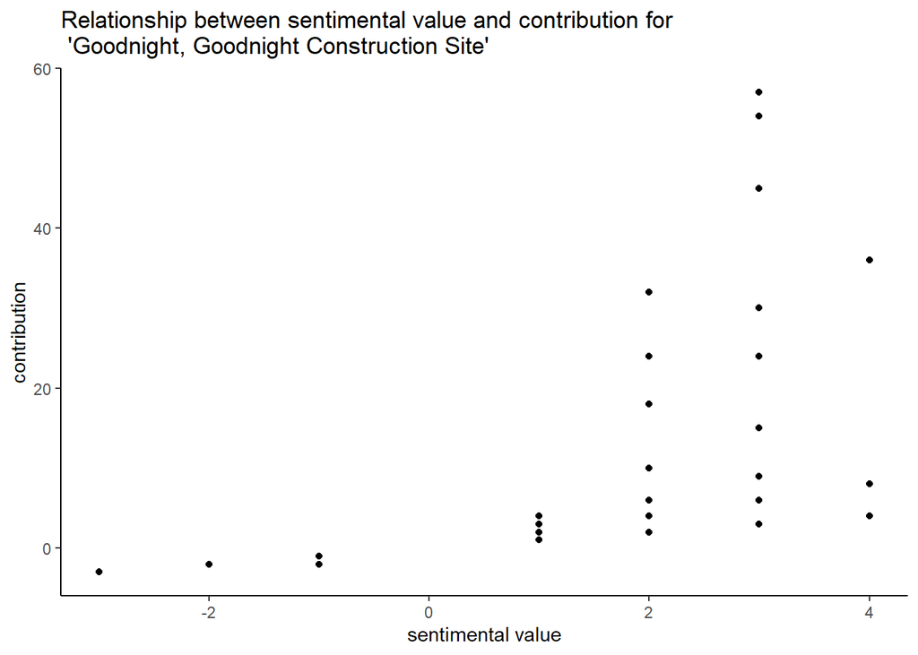

```r
ggcs<-rdata3%>%filter(product_title == "Goodnight, Goodnight Construction Site")
ggcsdata<-ggcs %>%
    unnest_tokens(word, review_body) %>%
    count(word, sort = TRUE) %>%
    ungroup() %>%
    inner_join(get_sentiments("afinn"), by = "word") %>%
    group_by(word) %>%
    mutate(contribution = value*n) %>%
    arrange(desc(abs(contribution)))

ggplot(ggcsdata, aes(y = contribution, x = value,colors=)) + geom_point() +
  labs(title="Relationship between sentimental value and contribution for\n 'Goodnight, Goodnight Construction Site'", x="sentimental value")+theme_classic()
```

As expected, most of the words are positive. Let’s see if someone is manipulating the reviews by examing the reviews from the not verified purchases:

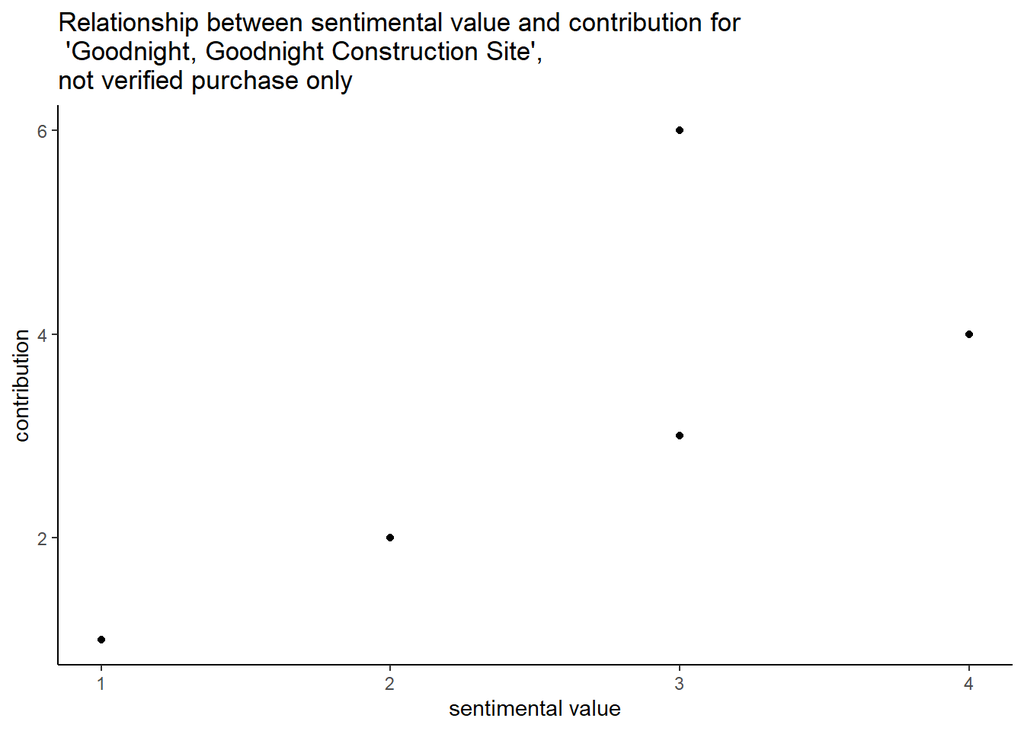

```r
ggcsv<-ggcs%>%filter(verified_purchase=="N")
ggcsvdata<-ggcsv %>%
    unnest_tokens(word, review_body) %>%
    count(word, sort = TRUE) %>%
    ungroup() %>%
    inner_join(get_sentiments("afinn"), by = "word") %>%
    group_by(word) %>%
    mutate(contribution = value*n) %>%
    arrange(desc(abs(contribution)))

ggplot(ggcsvdata, aes(y = contribution, x = value)) + geom_point()+
  labs(title="Relationship between sentimental value and contribution for\n 'Goodnight, Goodnight Construction Site', \nnot verified purchase only", x="sentimental value")+theme_classic()
```

Generally there are not a lot of unverifed comment so I would say there is no comment manipulation

###### Go Pro: 7 Steps to Becoming a Network Marketing Professional:

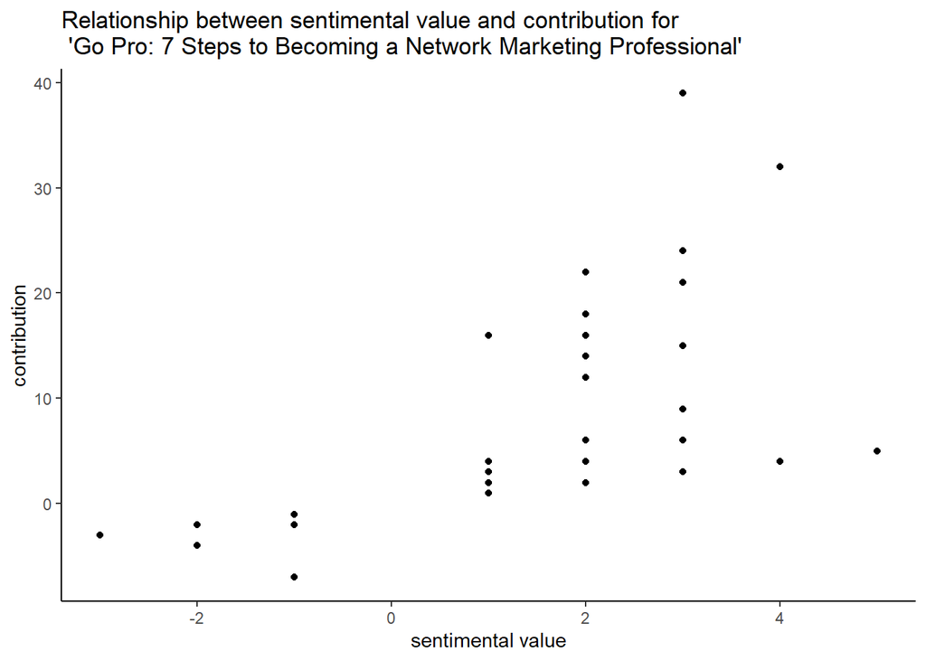

```r
gp7s<-rdata3%>%filter(product_title == "Go Pro: 7 Steps to Becoming a Network Marketing Professional")
gp7sdata<-gp7s %>%
    unnest_tokens(word, review_body) %>%
    count(word, sort = TRUE) %>%
    ungroup() %>%
    inner_join(get_sentiments("afinn"), by = "word") %>%
    group_by(word) %>%
    mutate(contribution = value*n) %>%
    arrange(desc(abs(contribution)))

ggplot(gp7sdata, aes(y = contribution, x = value)) + geom_point()+ labs(title="Relationship between sentimental value and contribution for\n 'Go Pro: 7 Steps to Becoming a Network Marketing Professional'", x="sentimental value")+theme_classic()
```

Again, no surprise most of the words are positive Let’s see if someone is manipulating reviews by examing the cooments from the not verified purchases:

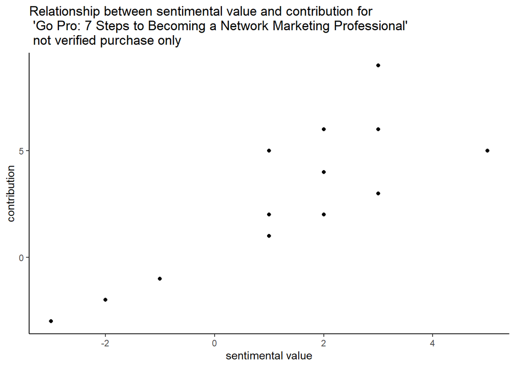

```r
gp7sv<-gp7s%>%filter(verified_purchase=="N")
gp7svdata<-gp7sv %>%
    unnest_tokens(word, review_body) %>%
    count(word, sort = TRUE) %>%
    ungroup() %>%
    inner_join(get_sentiments("afinn"), by = "word") %>%
    group_by(word) %>%
    mutate(contribution = value*n) %>%
    arrange(desc(abs(contribution)))

ggplot(gp7svdata, aes(y = contribution, x = value)) + geom_point()+ labs(title="Relationship between sentimental value and contribution for\n 'Go Pro: 7 Steps to Becoming a Network Marketing Professional'\n not verified purchase only", x="sentimental value")+theme_classic()
```

doesn’t look like there is manipulation either

##### The two top negative ones:

###### To Train Up a Child:

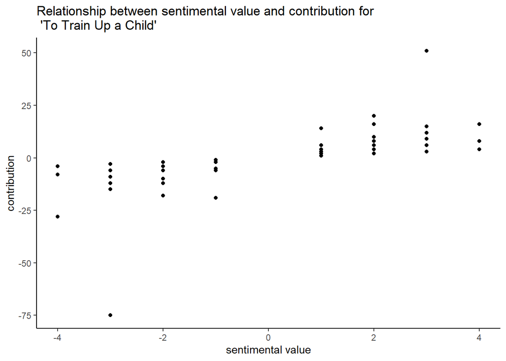

```r
ttuc<-rdata3%>%filter(product_title == "To Train Up a Child")
ttucdata<-ttuc %>%
    unnest_tokens(word, review_body) %>%
    count(word, sort = TRUE) %>%
    ungroup() %>%
    inner_join(get_sentiments("afinn"), by = "word") %>%
    group_by(word) %>%
    mutate(contribution = value*n) %>%
    arrange(desc(abs(contribution)))

ggplot(ttucdata, aes(y = contribution, x = value)) + geom_point()+ labs(title="Relationship between sentimental value and contribution for\n 'To Train Up a Child'", x="sentimental value")+theme_classic()
```

About half of the words are positive and half are negative, guess not everyone hates it No let’s find of if there is manipulation

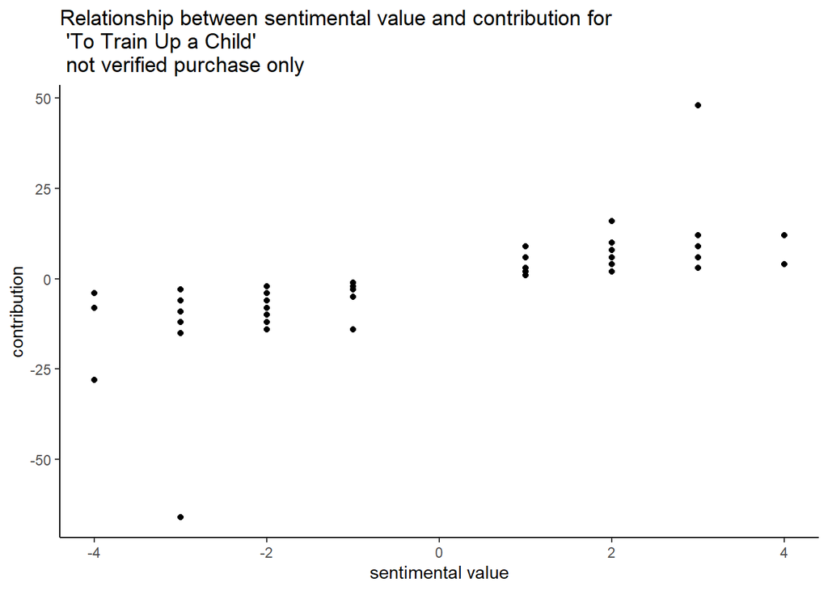

```r
ttucv<-ttuc%>%filter(verified_purchase=="N")
ttucvdata<-ttucv %>%
    unnest_tokens(word, review_body) %>%
    count(word, sort = TRUE) %>%
    ungroup() %>%
    inner_join(get_sentiments("afinn"), by = "word") %>%
    group_by(word) %>%
    mutate(contribution = value*n) %>%
    arrange(desc(abs(contribution)))

ggplot(ttucvdata, aes(y = contribution, x = value)) + geom_point()+labs(title="Relationship between sentimental value and contribution for\n 'To Train Up a Child' \n not verified purchase only", x="sentimental value")+theme_classic()
```

This is intresting. We can see it looks similar to the one with all the purchases, so that most of the words are actually from unverified comments. Now lets take a look at the verifed purchase reviews

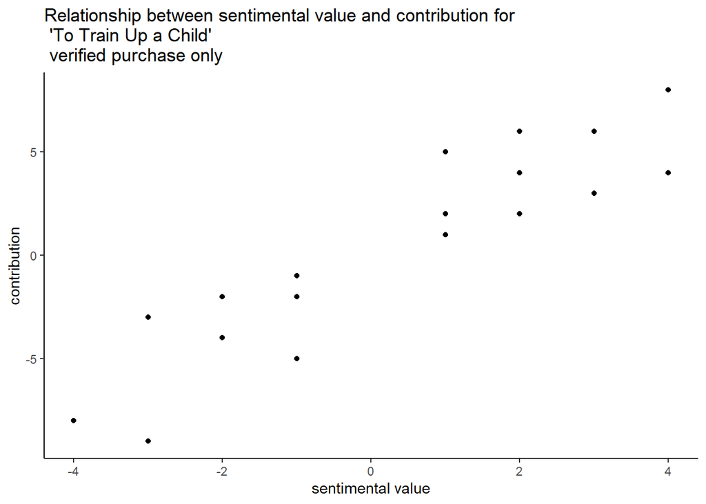

```r
ttucv<-ttuc%>%filter(verified_purchase=="Y")
ttucvdata<-ttucv %>%
    unnest_tokens(word, review_body) %>%
    count(word, sort = TRUE) %>%
    ungroup() %>%
    inner_join(get_sentiments("afinn"), by = "word") %>%
    group_by(word) %>%
    mutate(contribution = value*n) %>%
    arrange(desc(abs(contribution)))

ggplot(ttucvdata, aes(y = contribution, x = value)) + geom_point() + labs(title="Relationship between sentimental value and contribution for\n 'To Train Up a Child' \n verified purchase only", x="sentimental value")+theme_classic()
```

However, the distribution of those verified purchases look similar to that of the unverified ones, so we are not really sure if there is a bot activity or manipulting of comments here

###### It Could Happen To Anyone: Why Battered Women Stay

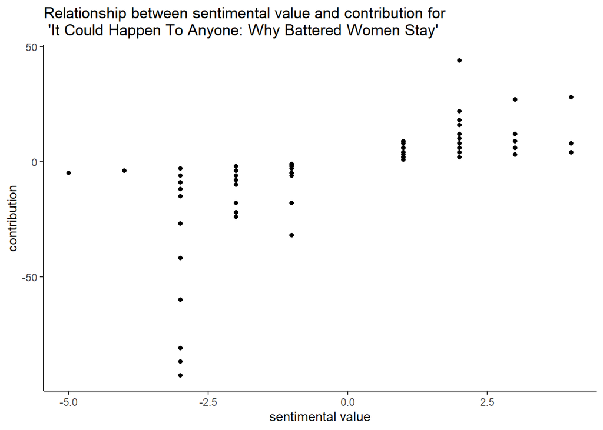

```r
icht<-rdata3%>%filter(product_title == "It Could Happen To Anyone: Why Battered Women Stay")

ichtdata<-icht %>%
    unnest_tokens(word, review_body) %>%
    count(word, sort = TRUE) %>%
    ungroup() %>%
    inner_join(get_sentiments("afinn"), by = "word") %>%
    group_by(word) %>%
    mutate(contribution = value*n) %>%
    arrange(desc(abs(contribution)))

ggplot(ichtdata, aes(y = contribution, x = value)) + geom_point()+labs(title="Relationship between sentimental value and contribution for\n 'It Could Happen To Anyone: Why Battered Women Stay'", x="sentimental value")+theme_classic()
```

Let’s try to find if there is manipulation

[figure not shown]

```r
ichtv<-icht%>%filter(verified_purchase=="Y")
ichtvdata<-ichtv %>%
    unnest_tokens(word, review_body) %>%
    count(word, sort = TRUE) %>%
    ungroup() %>%
    inner_join(get_sentiments("afinn"), by = "word") %>%
    group_by(word) %>%
    mutate(contribution = value*n) %>%
    arrange(desc(abs(contribution)))

ggplot(ichtvdata, aes(y = contribution, x = value)) + geom_point()+geom_point()+labs(title="Relationship between sentimental value and contribution for\n 'It Could Happen To Anyone: Why Battered Women Stay'\n verified purchase only", x="sentimental value")+theme_classic()
```

Now this is very intresting because all the reviews for this book are not verified!

```r
rdata3%>%filter(verified_purchase=="Y")%>%count()
```

```
## # A tibble: 1 x 1
##        n
##    <int>
## 1 334437
```

```r
rdata3%>%filter(verified_purchase=="N")%>%count()
```

```
## # A tibble: 1 x 1
##        n
##    <int>
## 1 124350
```

we see that the majority of the review are actually verified so having all of the review unverified is actually weird Thus, this book probably has its reviews manipulated by its competitors

## 2

let’s examine the relationship between average sentiment value for all the words and the star rate for all the comments

Let’s calculate the average sentiment value for all the reviews first

```r
comment_sentiments<-
rdata3 %>%
    unnest_tokens(word, review_body) %>%
    inner_join(get_sentiments("afinn"), by ="word") %>% group_by(review_id)%>%summarise(mean_sentiment=mean(value))%>%  arrange(desc(abs(mean_sentiment)))
```

```r
summary(comment_sentiments)
```

```
##   review_id         mean_sentiment
##  Length:428060      Min.   :-5.000
##  Class :character   1st Qu.: 1.000
##  Mode  :character   Median : 2.000
##                     Mean   : 1.686
##                     3rd Qu.: 2.667
##                     Max.   : 5.000
```

```r
everythingforcomment<-inner_join(comment_sentiments,rdata3, by="review_id")
everythingforcomment
```

```
## # A tibble: 428,060 x 15
##    review_id mean_sentiment customer_id.x product_title helpful_votes
##    <chr>              <dbl>         <dbl> <chr>                 <dbl>
##  1 R10APQJG~              5      25991404 Unbelonging,~             1
##  2 R111RDTV~              5      36241871 Acing the IB~             0
##  3 R11COUME~              5      50924285 Thea Stilton~             6
##  4 R11PF7Q0~              5      41363332 Unbroken: A ~             0
##  5 R11ZPQMA~              5      12855828 The Beekman ~             0
##  6 R12CJB3W~              5      12982572 Blue Moon Pr~             0
##  7 R12EV13C~              5      23995354 7 Miles A Se~             2
##  8 R132PMSG~              5      24744038 The Witcher ~             0
##  9 R136IF01~              5      35154296 Jesus Callin~             0
## 10 R13RQINV~              5      13432891 The Wolfe Wi~             0
## # ... with 428,050 more rows, and 10 more variables:
## #   review_headline <chr>, review_date <date>, customer_id.y <dbl>,
## #   product_id <chr>, product_parent <chr>, total_votes <dbl>, vine <chr>,
## #   verified_purchase <chr>, review_body <chr>, star_rating <dbl>
```

We want to tell the difference between vine memberes and non vine memberes

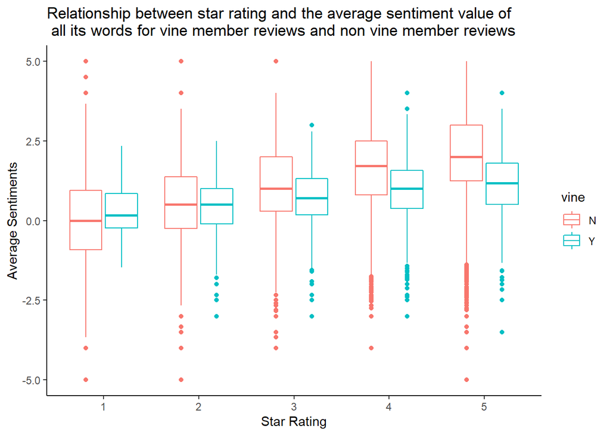

```r
ggplot(everythingforcomment,mapping=aes(y=mean_sentiment,x=factor(star_rating), colour=vine))+geom_boxplot()+labs(title="Relationship between star rating and the average sentiment value of \n all its words for vine member reviews and non vine member reviews",x="Star Rating", y="Average Sentiments")+theme_classic()
```

As expected, the higher the star rating of a review is, the higher the average sentiment of its words are. We can see that vine members tend to use more moderate language in their review when the star rating is the same, in that their reviews have higher sentiment value when star rating is below 3 and lower sentiment when the star rating is and over 3

Now we want to tell the difference verified purchases and not verified purchases

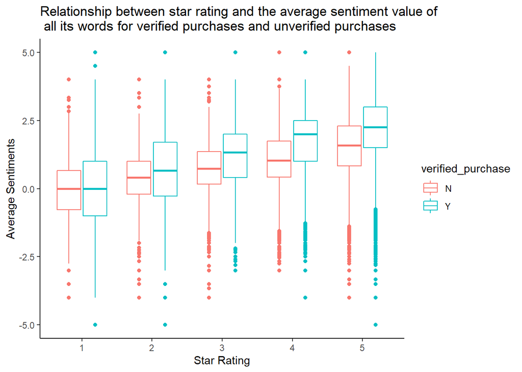

```r
ggplot(everythingforcomment,mapping=aes(y=mean_sentiment,x=factor(star_rating), colour=verified_purchase))+geom_boxplot()+ labs(title="Relationship between star rating and the average sentiment value of \n all its words for verified purchases and unverified purchases",x="Star Rating", y="Average Sentiments")+theme_classic()
```

Again, as expected, the higher the star rating of a review is, the higher the average sentiment of its words are. It looks like generally reviews from verified purchase are more positive when the star rating is the same.

## 3

My hypothesis is that those reviewers who write more reviews are gonna give a higher average star rating, for they probably have the habit of wrting reviews while others who write less reviews may only write review because they had a bad shopping experience

pseudocode: I am gonna group the data by costumer id and make a dot plot of the number of a costumer’s review and the average star rating he or she gives, and then try to make a line to fit it

```r
customer_data<-
everythingforcomment%>% group_by(customer_id.x)%>%summarise(average_star=mean(star_rating), number_of_review=n())
customer_data
```

```
## # A tibble: 359,723 x 3
##    customer_id.x average_star number_of_review
##            <dbl>        <dbl>            <int>
##  1         10072            5                1
##  2         10234            5                1
##  3         10419            5                1
##  4         10482            5                1
##  5         10925            2                1
##  6         10977            5                1
##  7         11467            5                1
##  8         11528            5                1
##  9         11658            5                1
## 10         11799            5                1
## # ... with 359,713 more rows
```

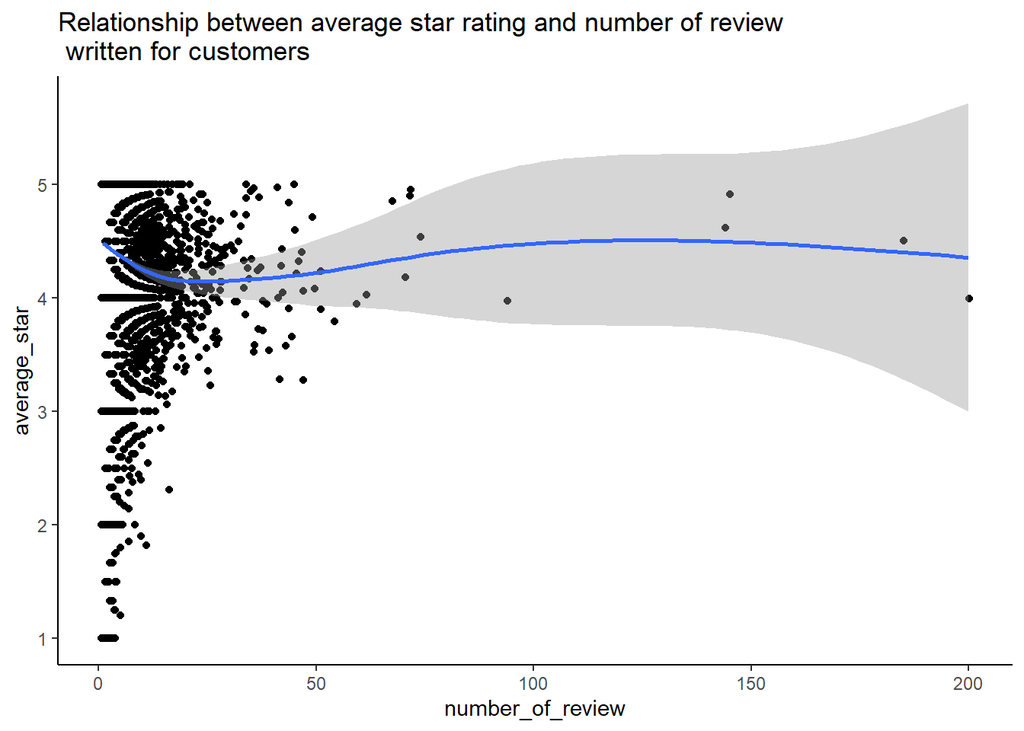

```r
ggplot(customer_data,mapping=aes(x=number_of_review,y=average_star))+geom_jitter()+labs(title="Relationship between average star rating and number of review\n written for customers")+theme_classic()+geom_smooth()
```

Well it turns out my hypothesis is wrong. Actually when the customer wrote small number of reviews those revies tend to me more positive. Its probably because people like to write comments not only when they dislike a book, but also when they like the book. It could also be because sellers are using bot accounts to post positive reviews to boost the average star rating of the product